# Projects, Environments, and Assistants

The tools you know now and how they fit together

DSCI 521

## Which tool gets you out of it?

--- shuffle_answers: true --- ## Situations you now know how to fix! Which tool gets you out of each one? > For each one, work out what kind of thing has gone wrong before you decide what to type. - You cloned this week's lab repo, opened the notebook, and the first `import pandas` fails. :: uv > The repo carries a lockfile and no `.venv`. `uv sync` builds the environment the pyproject.toml and lockfile describe, and you can `uv run jupyter lab`. - You are about to hand in the lab and want to see every line you changed since your last commit. :: git > `git diff` will show you a record of what you changed. - Your script says the data file does not exist, and you are not sure which folder you started from. :: bash > `pwd` tells you where you are, `ls` what is there. - A teammate's version of a paragraph replaced yours, and you want yesterday's wording back. :: git > `git log` helps to find the commit, `git restore --source sha` brings the file back. - You need a plotting package, and your two teammates have to use the same version after cloning the repo. :: uv > `uv add matplotlib` installs it and writes `pyproject.toml` and `uv.lock`, so the version travels with the commit. - You want a copy of last week's folder to experiment in, without touching the original. :: bash > `cp -r` does it in one line. - :: quarto > Quarto renders documents. It does not install packages, move files, or remember what your file said yesterday.

## Your environment, your editor, and git work together

[figure not shown]

**`uv` and `{renv}` manage the toolboxes.** One set of tools per project. You do not use the fish knife on the carpentry.

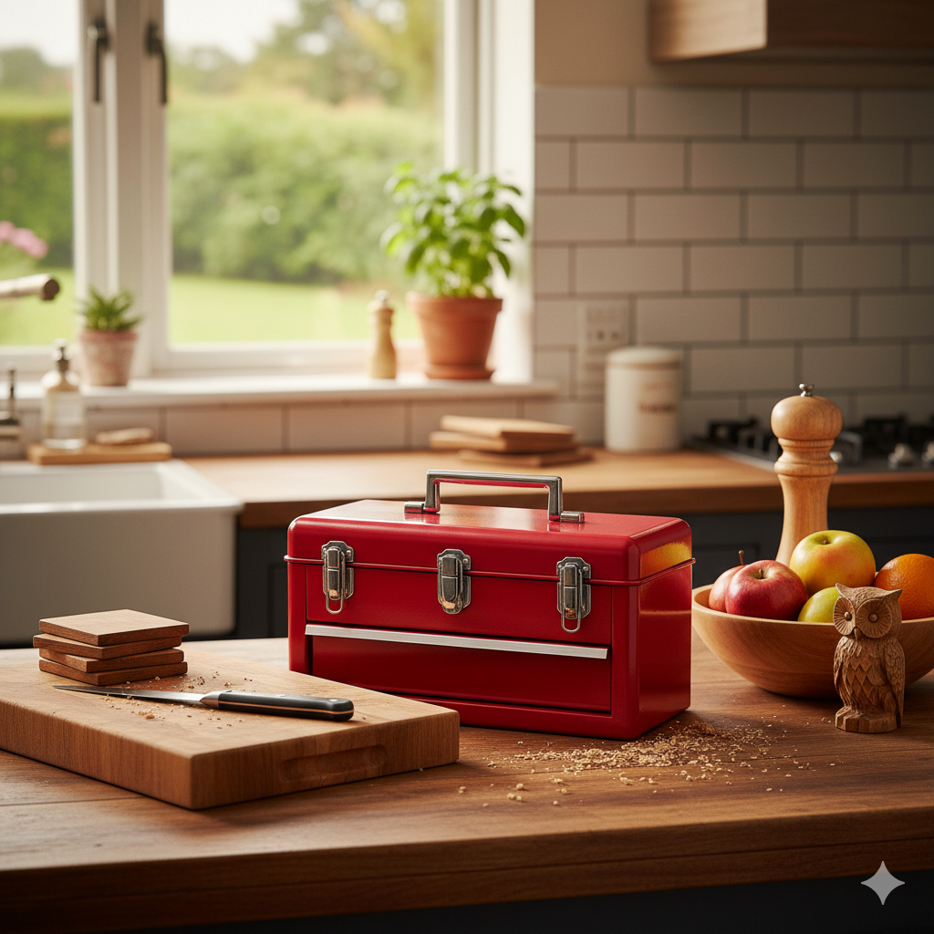

**Your IDE is the countertop.** JupyterLab, RStudio and Positron give you an empty surface on which everything comes together, but you still have to put the right toolboxes on it.

[figure not shown]

**Git is storage, teleporter and time machine.** It takes whatever you made, shares it with everyone, and can also magically restore what you broke (kinda?).

## Everything we covered and how it builds for what is still ahead

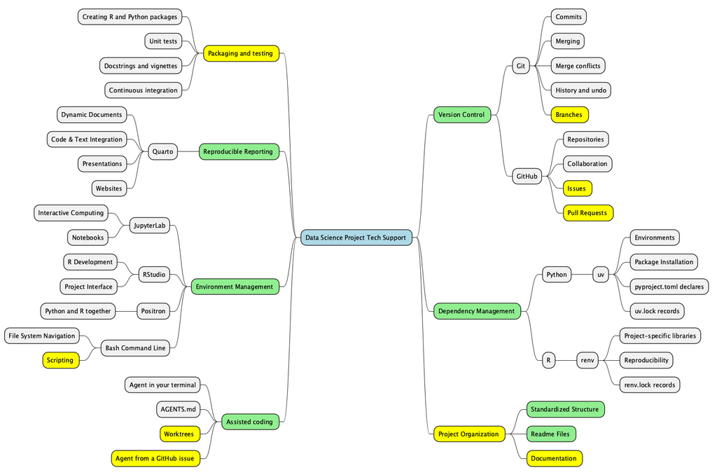

## Each connection between them removes a step you would otherwise do by hand

- *Git and your IDE*: JupyterLab, Positron and RStudio all show you changed files, staged files and the diff, so you stop guessing what `git status` will say.
- *Environment and your IDE*: point the editor at the project’s environment once (or just start it from the right folder), and every notebook you open there runs against the right packages.
- *Environment and git*: commit `pyproject.toml`, `uv.lock` and `.python-version` (or `renv.lock`), and the environment travels with the code.

## Human side of project org

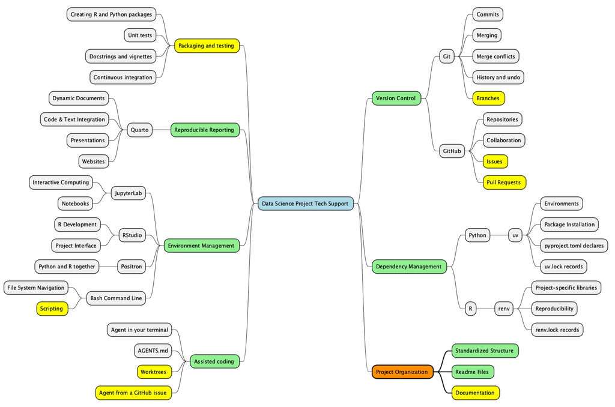

## Optimize for people and reproducibility

[Project organization chapter](https://ubc-mds.github.io/DSCI_521_platforms-dsci_book/lectures/regex-filenames-project-organization.html)

```
project/
├── data/
│   ├── raw/          never overwritten
│   └── processed/
├── reports/          *.ipynb *.qmd
├── src/              *.py *.R
├── doc/
├── README.md
├── pyproject.toml    what it declares
└── uv.lock           what it got
```

(more in 522 and 524) This or similar shape most data analysis projects settle into, and each location aimed to answer one question about a file: is it evidence, is it a result, is it code, is it text.

`data/raw/` comes with a rule attached: whatever came from outside goes in and is never written over from internal project tools. Everything else can be rebuilt from it and the code.

The last two lines (or `renv.lock` for R): the project carries its own environment blueprints (but no binaries).

## Organizing for humans – and automation: Filenames

[Filenames section](https://ubc-mds.github.io/DSCI_521_platforms-dsci_book/lectures/regex-filenames-project-organization.html#three-principles-for-file-names)

**Machine readable.** No spaces and punctuation beyond `_` and `-`: delimiter for fields and another inside dates. Then `ls *_report.csv` finds them, and so does a pattern search.

**Human readable.** The name says what is in the file. `2026-09-22_penguins-by-island.csv` tells you; `final2_REAL.csv` does not.

**Sorts the way you want by default.** Dates as `YYYY-MM-DD`, numbers padded with zeros: `fig-01`, `fig-02`, … `fig-10`. Otherwise `fig-10` sorts before `fig-2`.

```
$ ls
2026-09-08_penguins_raw.csv
2026-09-15_penguins_clean.csv
2026-09-22_penguins-by-island.csv

$ ls 2026-09-*_penguins_*.csv
2026-09-08_penguins_raw.csv
2026-09-15_penguins_clean.csv
```

The glob works because the fields are in fixed positions and the delimiters are consistent. That is what “machine readable” means.

Extended pattern matching in terminal and programming languages allowing us to do more complex things is supported by [regular expressions (RegEx)](https://ubc-mds.github.io/DSCI_521_platforms-dsci_book/lectures/regex.html)

## Which of these do you want to deal with at 3 a.m. before the deadline?

--- shuffle_answers: true --- ## It is 3 a.m., the lab is due at 6am (we don't do it in MDS but I like DRAMA), and you are looking for the abstract you wrote last week. Which filename do you want to find? > Read each one as though you had two hundred files in the folder. 1. [x] `2026-06-08_abstract-for-sla.docx` > Date first, so it sorts chronologically. Words say what it is. No spaces, no punctuation a shell would choke on. 1. [ ] `Joe's Filenames Use Spaces and Punctuation.xlsx` > Spaces and an apostrophe mean you have to quote or escape this every time you name it on the command line. 1. [ ] `figure 1.png` > A space, no date, and no clue which figure of which analysis. At `figure 10.png` it will also sort before `figure 2.png`. 1. [ ] `JW7d^(2sl@deletethisandyourcareerisoverWx2*.txt` > Machine readable in the narrowest sense and unreadable by you. `*` is a shell wildcard, so the name expands to something else the moment you type it. 1. [ ] `myabstract.docx` > Readable, but there is no date and no topic, so the second abstract you write has nowhere to go.

## What happens now? The tools are still the same, but you can delegate

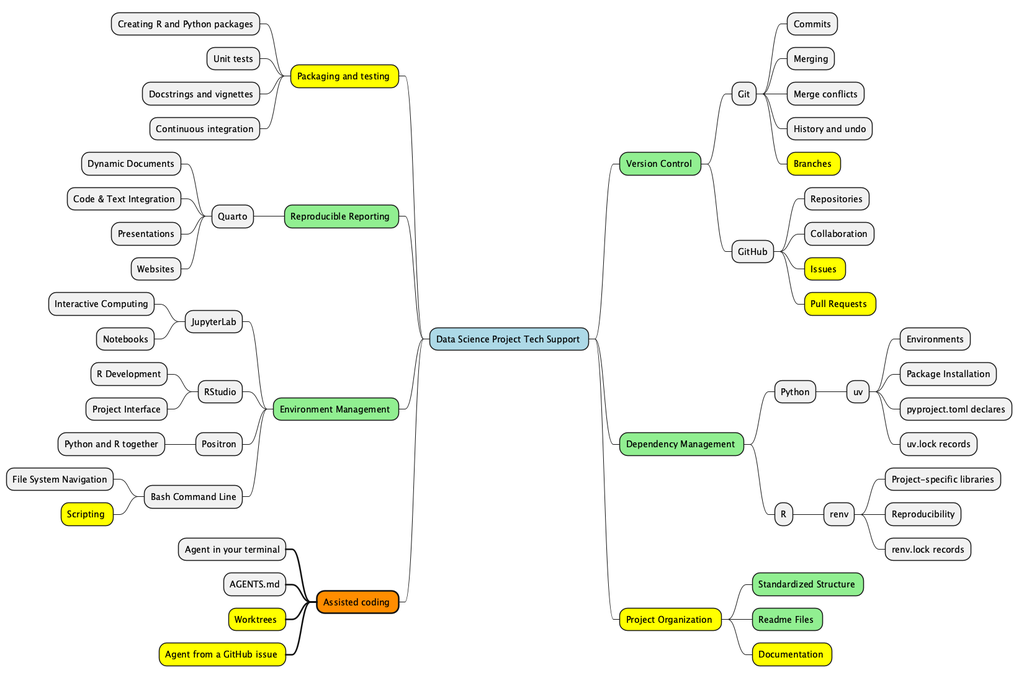

## An assistant runs the same commands you do

```
$ claude -p "Add a cell that draws an altair
  scatter chart of the dataframe. Install
  altair into the project first."

Done. Altair is installed in the project and the
notebook now ends with a one-cell interactive
scatter chart of the courses dataframe.

$ git status --short
 M lab0a.ipynb
 M pyproject.toml
 M uv.lock
?? lab0a.html
?? lab0a_files/
```

This is not autocomplete, it is an execution (in your name, Sire!). It read the notebook, ran `uv add altair`, edited a file, and rendered the notebook, using **your shell, your credentials and your project**.

Which means the things you learned this term are the things you supervise it with. You already know how to ask what changed.

## Now your folder and environment is in the blast radius, git is to rescue

```
$ git restore .
$ git status --short
?? lab0a.html
?? lab0a_files/

$ uv sync
Resolved 141 packages in 2ms
Uninstalled 2 packages in 30ms
 - altair==6.3.0
 - narwhals==2.26.0

$ uv run python -c "import altair"
ModuleNotFoundError: No module named 'altair'
```

If something went wrong, `git restore` returns the files you changed but had not staged. `uv sync` returns the environment to the lockfile, which means removing what does not belong there, including packages that arrived as dependencies.

What it does not touch is the two files the agent left behind: those were never tracked, so git has no earlier version of them. `make clean` or `rm` is what removes those.

That is why the rule is: commit before you let it run and make the agent to use git as well. Not because it will necessarily break something (but it will!), but because a file you never committed has no earlier version to go back to.

## Read the diff, not only the AI summary

**LLM**: “the notebook now ends with a one-cell interactive scatter chart”.

**Reality**:

```
$ git diff --stat
 lab0a.ipynb    | 450 +++++++++++++++++++++-----
 pyproject.toml |   2 +
 uv.lock        |  37 ++++-
 3 files changed, 460 insertions(+), 29 deletions(-)
```

One cell, 450 changed lines in the notebook, and two more files it did not put in that sentence.

None of that is wrong on its own. `uv add altair` is supposed to touch all three. The point is that the GenAI prose is a summary written by the thing being summarised, and `git diff` is not. Once something is staged, use `git diff --staged` to see it.

The 450 lines are why notebooks are hard to review: the cell is short, but running it writes the chart and its data into the file as output. That is what `nbdime` was for.

## Commit is your record, but chat is not

- The agent reasoning lives in a session on your laptop. Your teammates cannot see it, the marker cannot see it, and you will not see it next month (or, well, *sooner*).
- The repository is the only **durable, shared account** of what changed (protect the repo! more in 524). Commit the files your teammates and your marker need to see. Unless you expose your credentials, nothing in the chat window reaches them.
- So: commit before you start, and again after you have read the diff. Write the message **yourself**: it is the one piece of the session that survives.

## `AGENTS.md` tells GenAI assistant how to run your project

[AGENTS.md standard](https://agents.md/)

```
AGENTS.md
```

```markdown
# DSCI 521 lab

Python lives in the project's own
environment. Never use system Python.

## Commands
- Install:    `uv sync`
- Run a file: `uv run python <file>`
- Notebook:   `uv run jupyter lab`
- Render:     `uv run quarto render`

## House rules
- Do not edit files under `data/raw/`.
- Add packages with `uv add`, never
  with `pip install`.
```

A plain markdown file at the top of the repo. Claude Code (recently) and Copilot both read it when they start work in the repo.

Most of what goes in one is how to build and run the project.

It is the file that encourages an assistant not to do what forgetful students do and reach out for the system Python, and it is worth writing for the same reason a README.md is: the next person to open this repo (or clones it and collaborates, with their own assistant on board) does not know what you know.

## A prompt is the minimal reproducible example you already know

[Asking effective questions](https://ubc-mds.github.io/DSCI_521_platforms-dsci_book/lectures/asking-questions.html)

**Not this**

> it says module not found, can you fix it

Nothing here says which module, which command, which project, or what you already tried.

**This**

> `uv run python src/clean.py` fails with `ModuleNotFoundError: No module named 'altair'`. `pyproject.toml` lists altair and `uv sync` reports nothing to do. Notebook works, script does not.

The second one can be answered – by person, or by GenAI. The first is a *mystery wrapped in a riddle inside an enigma*.

Use the same rules from the asking-questions chapter: build a minimal reproducible example (or MRE). Say what you ran, what happened, what you expected, and what you already tried. Provide logs and screenshots of both what *you* typed and what *system replied*.

## Where this goes next

- **Worktrees.** Git enables cool GenAI work: One folder per branch, so several assistants can work on the same repository at once without standing on each other. Needs branches (522/524) and enables evolutionary improvement of your work by multiple agents. [Claude and worktrees](https://code.claude.com/docs/en/worktrees)
- **Agents you call from an issue.** Instead of a terminal, you describe the job in a GitHub issue, mention the assistant, and it opens a pull request you review. Needs issues and pull requests, which are 524. [Copilot on Github.com](https://docs.github.com/en/copilot/get-started/quickstart-for-using-github-copilot-on-github-com)
- Both put the repository in the middle, as we did in 521!

## Section chair 🎩: It is Student Experience of Instruction (aka course evals). Your feedback shapes what comes next

- All instructors in your courses are looking forward to your feedback which helps us improve.
- Ten minutes of honest input improves our courses and supports the people who teach it.
- It is a lot: every month you will be asked to give feedback on four courses. Large chunk of time (hi block 4/5) you will be tired. Try still doing it.
- Program-level impressions (and frustrations) are better communicated to your section chair and co-directors
- Instructors can influence how they teach something (and to some extent what is taught), but not what is not and what doesn’t fit to 10 months
- Before leaving feedback, useful to take a look what’s next – maybe the thing you are looking for is coming next

**You**

Share what worked and what did not for you: lectures, labs, pacing, support, specific cool things.

**Your instructor**

Learns what to keep and what to change. Evaluations are how teaching improves (and also how instructors stay motivated).

**Next year’s cohort**

Takes a stronger version of this course, the way you took one shaped by last year’s feedback (e.g. in 521 you got no extra quiz on quiz weeks and small project instead of homeworks).

## It also helps your instructors and TAs

**Job searches**

Instructors and TAs submit evaluations as evidence of their teaching when they apply for positions.

**Tenure**

Tenure reviews read evaluations to judge teaching effectiveness. So especially important for junior folks – and we have many.

**Promotion**

Evaluations inform promotion and contract renewal.

More responses give a fairer, more accurate picture. A handful of replies almost always provides a distorted one.

## Useful feedback is specific

**Name it.** Point to the lecture, lab or activity you mean.

**Balance it.** Say what helped you learn, not only what did not (unless *nothing* of what the instructor did was helpful)

**Suggest a fix.** Say what would have worked better for you (and take a pause if you can’t come up with anything).

“The conflict exercise in lab 3 should explain what the first person committing should do” is something we can act on.

Responses are anonymous and reach instructors only after final grades are submitted.

Say what you would say to a colleague who asked how the course went.

Be strategically kind – say something that matters after the term ends when we receive the feedback.

## Now, back to instructor’s 👖: Let’s take ten minutes today

[figure not shown]

https://go.blueja.io/NzMAlolhT02xv351HhKdtQ

**What I am specifically interested in working or not:**

- Separate slides on git and situation-strategy approach,
- bash and git flash cards,
- 80% completion quizzes instead of ORCA ones,
- providing command logs

– what was useful, what would you add/drop/improve?

Sign in with your CWL. I will stop talking and give you the time now and we will go to a break

## Habits that survive the course

- With the environment and the code both on GitHub, almost everything is low stakes. Break things on purpose and learn.
- Test yourself instead of rereading. Mix questions from different courses, and come back to them a week later (return to reviews in the textbook or git/bash flash cards. Some instructors started to adopt them as well).
- Predict before you run a command, observe what happened, explain it, then check your explanation against the docs.
- Re-learning something you thought you knew feels bad. That is not a sign you are doing it wrong, just a sign of your mental maps reorganizing. Painful growth. I hate this stuff…

# Bye (for now)

- I will (hopefully) see you in block 6 for Experiments and Causal inference
- But I am still your section chair, so you can reach out on Slack and drop by to ICCS 189 - OH or not
- …and get some chocolate, encouragement and a bonus story about data science tools.

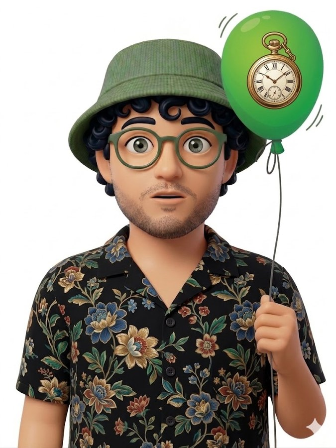